# Panggil library yang digunakan

```r
library("forecast")
```

```r
library("graphics")
library("TTR")
library("TSA")
```

## Impor Data

Data yang digunakan adalah data laporan mingguan rata-rata Harga Komoditas Telur di seluruh provinsi di Indonesia dalam 139 pekan (pekan 1 Januari 2021 hingga pekan 4 Agustus 2023)

```r
library(rio)
data1 <- import("https://raw.githubusercontent.com/karimatuain/mpdw/main/Data/Data%20MPDW%201.csv")
data1
```

```
##     Periode Harga
## 1         1 27600
## 2         2 27250
## 3         3 26550
## 4         4 25950
## 5         5 25400
## 6         6 25500
## 7         7 26000
## 8         8 25800
## 9         9 25750
## 10       10 27400
## 11       11 25350
## 12       12 25050
## 13       13 25600
## 14       14 25050
```

[output cut: 125 more lines]

```r
str(data1)
```

```
## 'data.frame':    139 obs. of  2 variables:
##  $ Periode: int  1 2 3 4 5 6 7 8 9 10 ...
##  $ Harga  : int  27600 27250 26550 25950 25400 25500 26000 25800 25750 27400 ...
```

```r
dim(data1)
```

```
## [1] 139   2
```

#Mengubah data agar terbaca sebagai data deret waktu dengan fungsi `ts()` .

```r
data1.ts <- ts(data1$Harga)
data1.ts
```

```
## Time Series:
## Start = 1
## End = 139
## Frequency = 1
##   [1] 27600 27250 26550 25950 25400 25500 26000 25800 25750 27400 25350 25050
##  [13] 25600 25050 26050 26300 26100 26050 26200 26000 29150 28450 26500 26400
##  [25] 26000 25750 25350 25350 26700 26150 26150 25350 26400 25150 24600 24000
##  [37] 23700 23350 23300 23250 23150 24000 23050 28550 25000 30050 25250 29800
##  [49] 24850 30550 27650 29950 30050 28850 27550 26400 23850 24500 24050 24200
##  [61] 24200 24900 25100 25250 25600 25700 25900 26150 27700 39350 27500 28500
##  [73] 28350 28800 29300 29350 29300 29100 29150 29350 29300 29450 29350 29150
##  [85] 30900 31050 31450 30850 30450 30050 28800 28100 28250 28400 28350 28350
##  [97] 28550 28900 29150 29950 30700 31250 31200 31100 30700 30500 30250 30050
## [109] 29750 29450 29250 28900 28550 28550 29250 30100 30200 30000 29850 29400
## [121] 30100 29850 30400 31400 31850 31950 31900 31700 31600 31800 31750 31850
## [133] 32000 32050 32000 31850 31650 31150 30600
```

#Menampilkan ringkasan data

```r
summary(data1.ts)
```

```
##    Min. 1st Qu.  Median    Mean 3rd Qu.    Max.
##   23050   25850   28550   28109   30050   39350
```

#Membuat plot data deret waktu

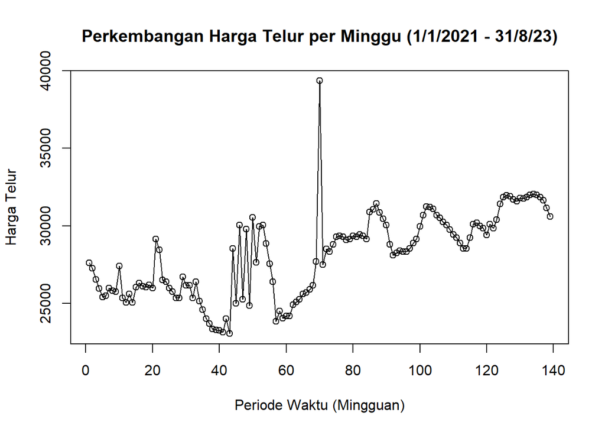

```r
ts.plot(data1.ts, xlab="Periode Waktu (Mingguan)", ylab="Harga Telur",
        main = "Perkembangan Harga Telur per Minggu (1/1/2021 - 31/8/23)")
points(data1.ts)
```

Tampak plot harga telur diatas menunjukkan bahwa data memiliki pola data tren. Meskipun harga telur fluktuatif namun rata-rata harganya cenderung memiliki tren harga meningkat setiap waktu.

#membagi data latih dan data uji (data latih 80%, data uji 20%)

```r
training_ma <- data1[1:111,]
training_ma
```

```
##     Periode Harga
## 1         1 27600
## 2         2 27250
## 3         3 26550
## 4         4 25950
## 5         5 25400
## 6         6 25500
## 7         7 26000
## 8         8 25800
## 9         9 25750
## 10       10 27400
## 11       11 25350
## 12       12 25050
## 13       13 25600
## 14       14 25050
```

[output cut: 97 more lines]

```r
testing_ma <- data1[112:139,]
testing_ma
```

```
##     Periode Harga
## 112     112 28900
## 113     113 28550
## 114     114 28550
## 115     115 29250
## 116     116 30100
## 117     117 30200
## 118     118 30000
## 119     119 29850
## 120     120 29400
## 121     121 30100
## 122     122 29850
## 123     123 30400
## 124     124 31400
## 125     125 31850
## 126     126 31950
## 127     127 31900
## 128     128 31700
## 129     129 31600
## 130     130 31800
## 131     131 31750
## 132     132 31850
## 133     133 32000
## 134     134 32050
## 135     135 32000
## 136     136 31850
## 137     137 31650
## 138     138 31150
## 139     139 30600
```

```r
train_ma.ts <- ts(training_ma$Harga)
test_ma.ts <- ts(testing_ma$Harga)
```

#Eksplorasi dengan GGPLOT

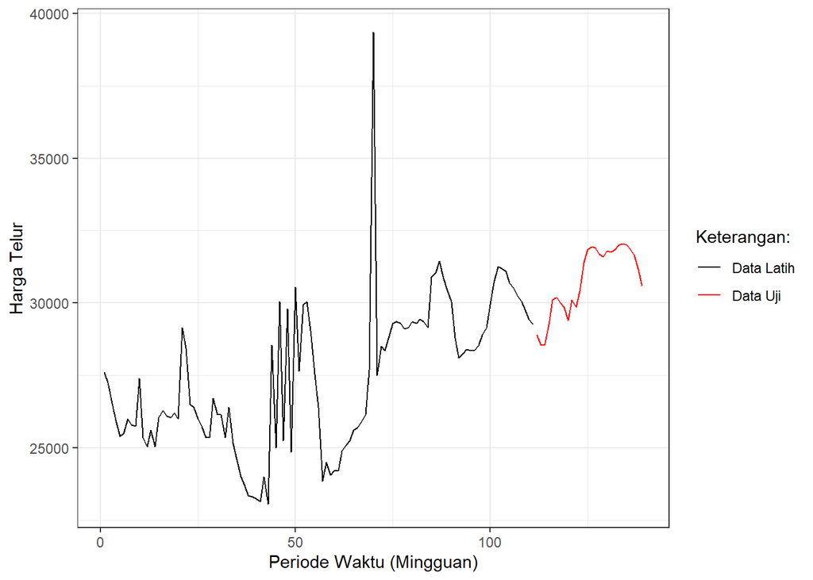

```r
library(ggplot2)
ggplot() +
  geom_line(data = training_ma, aes(x = Periode, y = Harga, col = "Data Latih")) +
  geom_line(data = testing_ma, aes(x = Periode, y = Harga, col = "Data Uji")) +
  labs(x = "Periode Waktu (Mingguan)", y = "Harga Telur", color = "Legend") +
  scale_colour_manual(name="Keterangan:", breaks = c("Data Latih", "Data Uji"),
                      values = c("black","red")) +
  theme_bw() + theme(legend.position = "right",
                     plot.caption = element_text(hjust=0.5, size=12))
```

# Percobaan pemulusan dengan Motode Double Moving Average (DMA)

Plot data menunjukkan adanya trend yang cenderung naik sehingga metode pemulusan Double Moving Average (DMA) dirasa lebih cocok digunakan. Proses pemulusan dengan rata rata dalam metode ini dilakukan sebanyak 2 kali.

```r
data.sma<-SMA(train_ma.ts, n=4)
dma <- SMA(data.sma, n = 4)
At <- 2*data.sma - dma
Bt <- 2/(4-1)*(data.sma - dma)
data.dma<- At+Bt
data.ramal<- c(NA, data.dma)

t = 1:28
f = c()

for (i in t) {
  f[i] = At[length(At)] + Bt[length(Bt)]*(i)
}

data.gab <- cbind(aktual = c(train_ma.ts,rep(NA,28)), pemulusan1 = c(data.sma,rep(NA,28)),pemulusan2 = c(data.dma, rep(NA,28)),At = c(At, rep(NA,28)), Bt = c(Bt,rep(NA,28)),ramalan = c(data.ramal, f[-1]))
data.gab
```

```
##        aktual pemulusan1 pemulusan2       At           Bt  ramalan
##   [1,]  27600         NA         NA       NA           NA       NA
##   [2,]  27250         NA         NA       NA           NA       NA
##   [3,]  26550         NA         NA       NA           NA       NA
##   [4,]  25950    26837.5         NA       NA           NA       NA
##   [5,]  25400    26287.5         NA       NA           NA       NA
##   [6,]  25500    25850.0         NA       NA           NA       NA
##   [7,]  26000    25712.5   24946.88 25253.12  -306.250000       NA
##   [8,]  25800    25675.0   25331.25 25468.75  -137.500000 24946.88
##   [9,]  25750    25762.5   25783.33 25775.00     8.333333 25331.25
##  [10,]  27400    26237.5   26888.54 26628.12   260.416667 25783.33
##  [11,]  25350    26075.0   26304.17 26212.50    91.666667 26888.54
##  [12,]  25050    25887.5   25715.62 25784.38   -68.750000 26304.17
##  [13,]  25600    25850.0   25579.17 25687.50  -108.333333 25715.62
##  [14,]  25050    25262.5   24418.75 24756.25  -337.500000 25579.17
```

[output cut: 125 more lines]

# Hasil pemulusan menggunakan metode DMA divisualisasikan sebagai berikut

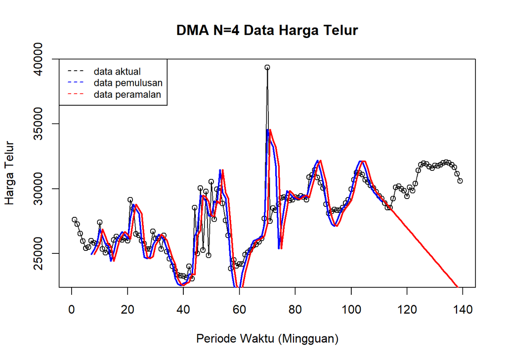

```r
ts.plot(data1.ts, xlab="Periode Waktu (Mingguan)", ylab="Harga Telur", main= "DMA N=4 Data Harga Telur")
points(data1.ts)
lines(data.gab[,3],col="blue",lwd=2)
lines(data.gab[,6],col="red",lwd=2)
legend("topleft",c("data aktual","data pemulusan","data peramalan"), lty=8, col=c("black","blue","red"), cex=0.8)
```

# Menghitung nilai keakuratan data latih (DMA)

Selanjutnya perhitungan akurasi dilakukan baik pada data latih maupun data uji. Perhitungan akurasi dilakukan dengan ukuran akurasi SSE, MSE dan MAPE.

```r
error_train.dma = train_ma.ts-data.ramal[1:length(train_ma.ts)]
SSE_train.dma = sum(error_train.dma[8:length(train_ma.ts)]^2)
MSE_train.dma = mean(error_train.dma[8:length(train_ma.ts)]^2)
MAPE_train.dma = mean(abs((error_train.dma[8:length(train_ma.ts)]/train_ma.ts[8:length(train_ma.ts)])*100))

akurasi_train.dma <- matrix(c(SSE_train.dma, MSE_train.dma, MAPE_train.dma))
row.names(akurasi_train.dma)<- c("SSE", "MSE", "MAPE")
colnames(akurasi_train.dma) <- c("Akurasi m = 4")
akurasi_train.dma
```

```
##      Akurasi m = 4
## SSE   4.752876e+08
## MSE   4.570073e+06
## MAPE  4.769854e+00
```

Perhitungan akurasi pada data latih menggunakan nilai MAPE menghasilkan nilai MAPE yang kurang dari 10% sehingga dikategorikan sangat baik. Selanjutnya, perhitungan nilai akurasi dilakukan pada data uji.

#Menghitung nilai keakuratan data uji (DMA)

```r
error_test.dma = test_ma.ts-data.gab[112:139,6]
SSE_test.dma = sum(error_test.dma^2)
MSE_test.dma = mean(error_test.dma^2)
MAPE_test.dma = mean(abs((error_test.dma/test_ma.ts*100)))

akurasi_test.dma <- matrix(c(SSE_test.dma, MSE_test.dma, MAPE_test.dma))
row.names(akurasi_test.dma)<- c("SSE", "MSE", "MAPE")
colnames(akurasi_test.dma) <- c("Akurasi m = 4")
akurasi_test.dma
```

```
##      Akurasi m = 4
## SSE   1.017349e+09
## MSE   3.633388e+07
## MAPE  1.664384e+01
```

### Percobaan Pemulusan dengan metode Double Exponential Smoothing (DES)

Metode pemulusan (DES) digunakan untuk data yang memiliki pola tren. Metode DES adalah metode semacam SES, hanya saja dilakukan dua kali, yaitu pertama untuk tahapan ‘level’ dan kedua untuk tahapan ‘tren’. Pemulusan menggunakan metode ini akan menghasilkan peramalan tidak konstan untuk periode berikutnya.

Untuk mendapatkan nilai parameter optimum dari DES, argumen `alpha` dan `beta` dapat dibuat `NULL` seperti berikut.

# Lamda dan gamma optimum

```r
des.opt<- HoltWinters(train_ma.ts, gamma = FALSE)
des.opt
```

```
## Holt-Winters exponential smoothing with trend and without seasonal component.
##
## Call:
## HoltWinters(x = train_ma.ts, gamma = FALSE)
##
## Smoothing parameters:
##  alpha: 0.4780944
##  beta : 0.03269766
##  gamma: FALSE
##
## Coefficients:
##          [,1]
## a 29545.92001
## b    13.47998
```

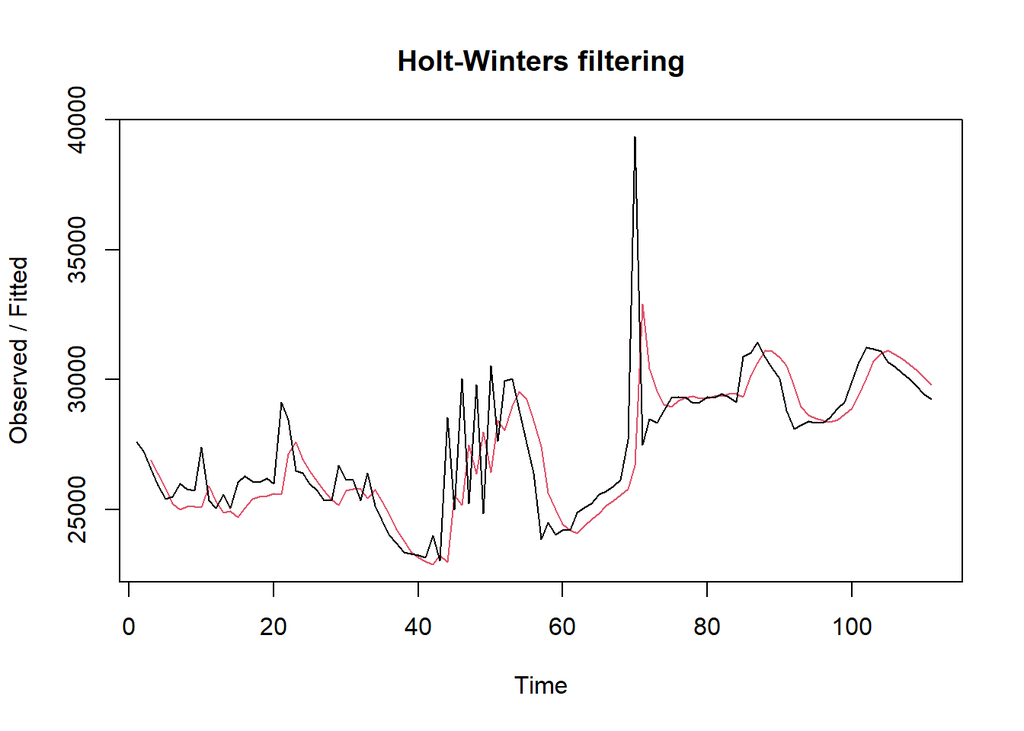

```r
plot(des.opt)
```

```r
# ramalan
ramalandesopt<- forecast(des.opt, h=28)
ramalandesopt
```

```
##     Point Forecast    Lo 80    Hi 80    Lo 95    Hi 95
## 112       29559.40 27159.11 31959.69 25888.47 33230.33
## 113       29572.88 26895.97 32249.79 25478.90 33666.86
## 114       29586.36 26643.47 32529.25 25085.60 34087.12
## 115       29599.84 26398.50 32801.18 24703.82 34495.86
## 116       29613.32 26158.98 33067.66 24330.36 34896.28
## 117       29626.80 25923.40 33330.20 23962.94 35290.66
## 118       29640.28 25690.66 33589.90 23599.86 35680.70
## 119       29653.76 25459.93 33847.59 23239.85 36067.67
## 120       29667.24 25230.55 34103.93 22881.91 36452.57
## 121       29680.72 25002.02 34359.42 22525.27 36836.17
## 122       29694.20 24773.92 34614.48 22169.29 37219.11
## 123       29707.68 24545.93 34869.43 21813.46 37601.90
## 124       29721.16 24317.75 35124.57 21457.36 37984.96
## 125       29734.64 24089.18 35380.10 21100.66 38368.62
## 126       29748.12 23860.02 35636.22 20743.05 38753.19
## 127       29761.60 23630.10 35893.09 20384.29 39138.91
## 128       29775.08 23399.31 36150.85 20024.18 39525.98
## 129       29788.56 23167.51 36409.61 19662.53 39914.58
## 130       29802.04 22934.61 36669.47 19299.22 40304.86
## 131       29815.52 22700.53 36930.50 18934.09 40696.95
## 132       29829.00 22465.20 37192.80 18567.04 41090.95
## 133       29842.48 22228.56 37456.40 18197.99 41486.97
## 134       29855.96 21990.54 37721.38 17826.84 41885.08
## 135       29869.44 21751.11 37987.77 17453.53 42285.35
## 136       29882.92 21510.22 38255.62 17077.99 42687.85
## 137       29896.40 21267.85 38524.95 16700.17 43092.63
## 138       29909.88 21023.95 38795.81 16320.03 43499.73
## 139       29923.36 20778.51 39068.21 15937.52 43909.20
```

# Plot untuk mengevaluasi prediksi

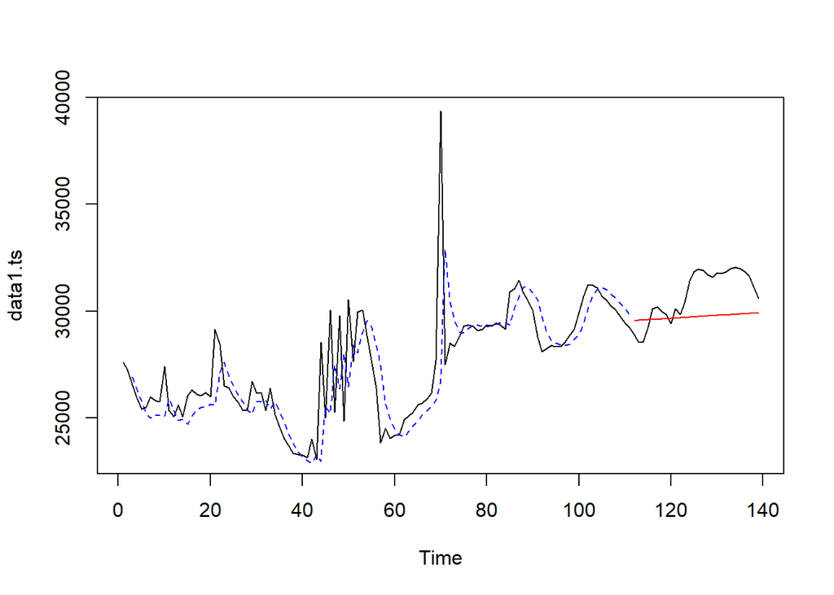

```r
plot(data1.ts)
lines(des.opt$fitted[,1], lty=2, col="blue")
lines(ramalandesopt$mean, col="red")
```

Selanjutnya akan dilakukan perhitungan akurasi pada data latih maupun data uji dengan ukuran akurasi SSE, MSE dan MAPE. #### Akurasi Data Latih (DES)

```r
ssedes.train<-des.opt$SSE
msedes.train<-ssedes.train/length(train_ma.ts)
sisaandes<-ramalandesopt$residuals
head(sisaandes)
```

```
## Time Series:
## Start = 1
## End = 6
## Frequency = 1
## [1]        NA        NA -350.0000 -427.1956 -410.8062  254.1695
```

```r
mapedes.train <- sum(abs(sisaandes[3:length(train_ma.ts)]/train_ma.ts[3:length(train_ma.ts)])
                      *100)/length(train_ma.ts)

akurasides.opt <- matrix(c(ssedes.train,msedes.train,mapedes.train))
row.names(akurasides.opt)<- c("SSE", "MSE", "MAPE")
colnames(akurasides.opt) <- c("Akurasi (optimum) lambda=0.48 dan gamma=0.03")
akurasides.opt
```

```
##      Akurasi (optimum) lambda=0.48 dan gamma=0.03
## SSE                                  3.838206e+08
## MSE                                  3.457843e+06
## MAPE                                 3.643727e+00
```

#### Akurasi Data Uji (DES)

```r
selisihdesopt<-ramalandesopt$mean-testing_ma$Harga
selisihdesopt
```

```
## Time Series:
## Start = 112
## End = 139
## Frequency = 1
##  [1]   659.4000  1022.8800  1036.3599   349.8399  -486.6801  -573.2001
##  [7]  -359.7201  -196.2402   267.2398  -419.2802  -155.8002  -692.3203
## [13] -1678.8403 -2115.3603 -2201.8803 -2138.4003 -1924.9204 -1811.4404
## [19] -1997.9604 -1934.4804 -2021.0005 -2157.5205 -2194.0405 -2130.5605
## [25] -1967.0805 -1753.6006 -1240.1206  -676.6406
```

```r
SSEtestingdesopt<-sum(selisihdesopt^2)
MSEtestingdesopt<-SSEtestingdesopt/length(testing_ma$Harga)
MAPEtestingdesopt<-sum(abs(selisihdesopt/testing_ma$Harga)*100)/length(testing_ma$Harga)

akurasitestingdes <-
  matrix(c(SSEtestingdesopt,MSEtestingdesopt,MAPEtestingdesopt),
         nrow=3,ncol=1)
row.names(akurasitestingdes)<- c("SSE", "MSE", "MAPE")
colnames(akurasitestingdes) <- c("DES optimum")
akurasitestingdes
```

```
##       DES optimum
## SSE  6.262932e+07
## MSE  2.236762e+06
## MAPE 4.122401e+00
```

Perhitungan akurasi menggunakan data latih dan data uji menghasilkan nilai MAPE yang kurang dari 10% sehingga nilai akurasi ini dapat dikategorikan sebagai sangat baik.